# Week 9 - Muddiest Points

Yuzi Zhang, Ph.D.  
zhang.15684@osu.edu

October 27, 2026

## Muddiest Points from Cox PH Regression Part I

Interpret Cox proportional hazards (PH) model results

- exponentiated $(\exp(\beta))$ vs. not exponentiated $(\beta)$
- interaction term

## Muddy Point - Interpretation: Log Hazard Ratio vs. Hazard Ratio

*Example*: A study enrolled 619 subjects with colon cancer

- Event = death; Survival time = time to death
- Covariates: `treatment` (0 = control, 1 = treatment); `age` (in years)

$h(t|\boldsymbol{x})$ = hazard function (instantaneous risk of event) – the chance an individual experiences the event in the next instant in time

$$\log\left( h(t) \right) = \log\left( h_0(t) \right) + \beta_1 \texttt{treatment} + \beta_2 \texttt{age}$$

$$h(t) = h_0(t) \exp\left( \beta_1 \texttt{treatment} + \beta_2 \texttt{age} \right)$$

## Muddy Point - Log Hazard Ratio vs. Hazard Ratio (Cont’d)

**Not exponentiated**

- $\beta_1$ = log hazard ratio comparing treatment to control, holding age constant.
- $\beta_2$ = log hazard ratio for a one year increase in age, holding treatment constant.

**Exponentiated**

- $\exp(\beta_1)$ = hazard ratio comparing treatment to control, holding age constant.
- $\exp(\beta_2)$ = hazard ratio for a one year increase in age, holding treatment constant.

**NOTE**: *Refer to Lecture 7B for details.*

## Muddy Point - Interpretation: Treatment Effect

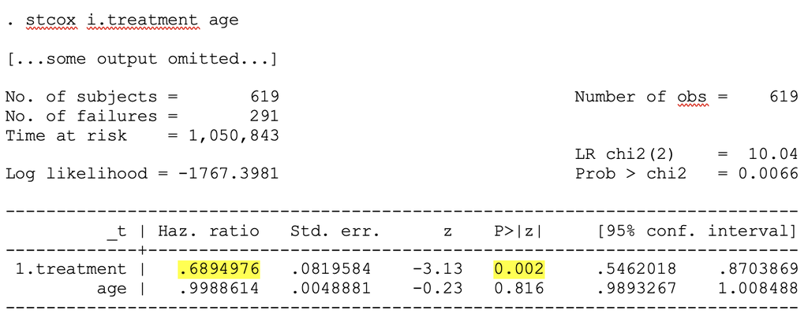

- $\exp(\hat{\beta}_1) = 0.689$

  When holding age constant, the instantaneous risk of death for subjects in the treatment group is 0.689 times that for subjects in the control group.
  - $100\times(1 - 0.689) = 31.1\%$ lower risk of death $\rightarrow$ the treatment is beneficial
  - $p$-value = 0.002 $\rightarrow$ significant effect

## Muddy Point - Interpretation: Age Effect

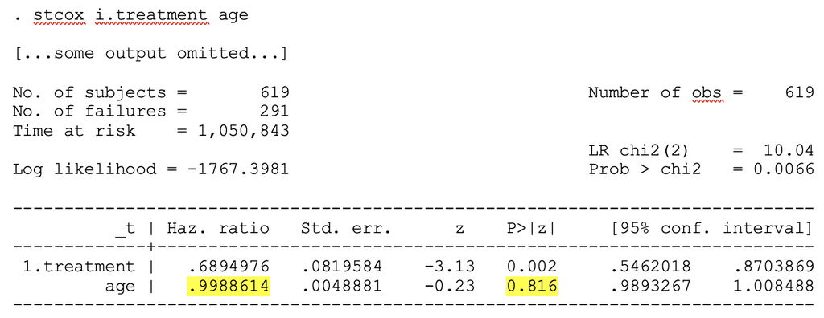

- $\exp(\hat{\beta}_2) = 0.999$

  When holding treatment constant, the instantaneous risk of death is 0.999 times that for a one year increase in age.
  - $p$-value = 0.816 $>$ 0.05 $\rightarrow$ age effect is not significant

## Muddy Point - Note on `Stata`

- By default, `stcox` command prints exponentiated coefficients, $\exp(\hat{\beta}_j)$, **hazard ratios**
  - Like the `logistic` command prints odds ratios
- To get the coefficients themselves, $\hat{\beta}_j$, option `nohr` should be used.
  - Like the `logit` command prints log odds ratios

## Muddy Point - Interpretation with Interaction Term

$$h(t) = h_0(t) \exp\left( \beta_1 \texttt{treatment} + \beta_2 \texttt{age} + \textcolor{#BB0000}{\beta_3 \texttt{treatment} \times \texttt{age}} \right)$$

With the interaction term

- The effect of treatment depends on age: $\beta_1 + \beta_3 \times \texttt{age}$
- The effect of age depends on treatment: $\beta_2 + \beta_3 \times \texttt{treatment}$

## Muddy Point - Treatment Effect Depends on Age

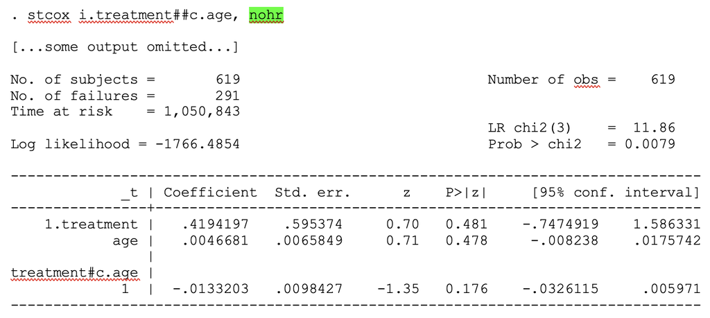

- $\hat{\beta}_1$ = 0.419, $\hat{\beta}_2$ = 0.005, $\hat{\beta}_3$ = -0.013
- The effect of treatment: $\hat{\beta}_1 + \hat{\beta}_3 \times \texttt{age} = 0.419 - 0.013 \times \texttt{age}$

  HR comparing treatment to control **decreases** as age increases
  - HR at age 60 = 0.684 *(check this by computing $\exp(0.4194197 - 0.0133203 \times 60)$)*
  - HR at age 65 = 0.640 *(check this by computing $\exp(0.4194197 - 0.0133203 \times 65)$)*

## Muddy Point - Age Effect Depends on Treatment

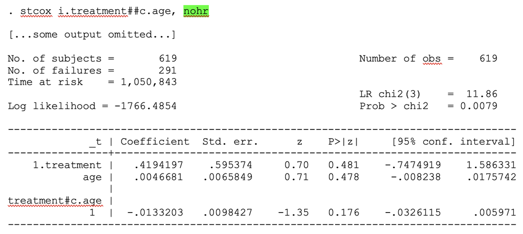

  Age effect is **smaller** for subjects in the treatment group compared to the control group.

## Muddy Point - Interpret Interaction Term

- $\exp(\hat{\beta}_3)$ = **ratio of two HRs**
- HRs comparing treatment to control for different ages
  - HR at age 60 is: $\exp(\hat{\beta}_1 + \hat{\beta}_3 \times 60)$
  - HR at age 61 is: $\exp(\hat{\beta}_1 + \hat{\beta}_3 \times 61)$
  - **Ratio of these two HRs** = $\dfrac{\exp(\hat{\beta}_1 + \hat{\beta}_3 \times 61)}{\exp(\hat{\beta}_1 + \hat{\beta}_3 \times 60)} = \exp(\hat{\beta}_3)$
- HRs associated with a 1-year increase in age for subjects in different treatment groups
  - HR for subjects in treatment is: $\exp(\hat{\beta}_2 + \hat{\beta}_3)$
  - HR for subjects in control is: $\exp(\hat{\beta}_2)$
  - **Ratio of these two HRs** = $\dfrac{\exp(\hat{\beta}_2 + \hat{\beta}_3)}{\exp(\hat{\beta}_2)} = \exp(\hat{\beta}_3)$